# Pixel-level sanitation factors

last run by: jvillasenor

March 03, 2020

Sanitation factors were calculated at the country level (for rural and urban) by Gordon here. Here, we’ll take those values and assign them to 1km pixels to obtain a gridded version of country-level sanitation factors dat account for urban / rural characteristics, as well as rivers. That gridded version can then be multiplied times population density (at the pixel level) total effluent FIO effluent.

Each country has two values of sanitation factors. One value is for urban, and another value is for rural, as seen here:

```r
sanit <- read.csv(sanit_factors_impute_fn,
                  stringsAsFactors = F) %>%
  select(ISO3, contains("_sf"), imputed_ml, imputed_r)

sanit
```

```
##     ISO3     rural_sf rural_sf_septic    urban_sf urban_sf_septic national_sf
## 1    ABW 0.0349388958    0.0001000000 0.017903774    0.0002264544 0.009506283
## 2    AFG 0.1954736470    0.0001000000 0.126690945    0.0008127250 0.177939232
## 3    AGO 0.1570453573    0.0001376858 0.037959602    0.0019061724 0.081490215
## 4    AIA 0.0507860907    0.0001031557 0.012082984    0.0001200000 0.012082984
## 5    ALA 0.0649458867    0.0058628289 0.018140943    0.0093229727 0.019385758
## 6    ALB 0.0155527705    0.0095526504 0.015900030    0.0099000000 0.009790458
## 7    AND 0.0159000000    0.0099000000 0.015900000    0.0099000000 0.015900000
## 8    ARE 0.0902193060    0.0043527834 0.018099453    0.0091993445 0.019786379
## 9    ARG 0.0004791704    0.0004780539 0.037014079    0.0062011820 0.005715630
## 10   ARM 0.1552885601    0.0019608614 0.017701634    0.0097189084 0.067941393
## 11   ASM 0.1203829503    0.0009661914 0.033307728    0.0059055261 0.031599441
## 12   ATA 0.0000000000    0.0000000000 0.000000000    0.0000000000 0.000000000
## 13   ATF 0.1967628000    0.0001000000 0.157517239    0.0008367104 0.182106435
## 14   ATG 0.1022304829    0.0001000000 0.020943238    0.0001398173 0.040745817
```

[output cut: 1065 more lines]

We can look at these values on a map

```r
world_vector_sf <- st_read(world_vector_fn) %>%
  left_join(sanit)
```

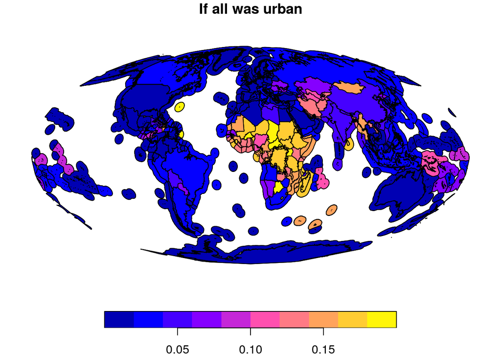

```r
plot(world_vector_sf[, "urban_sf"], main = "If all was urban")
```

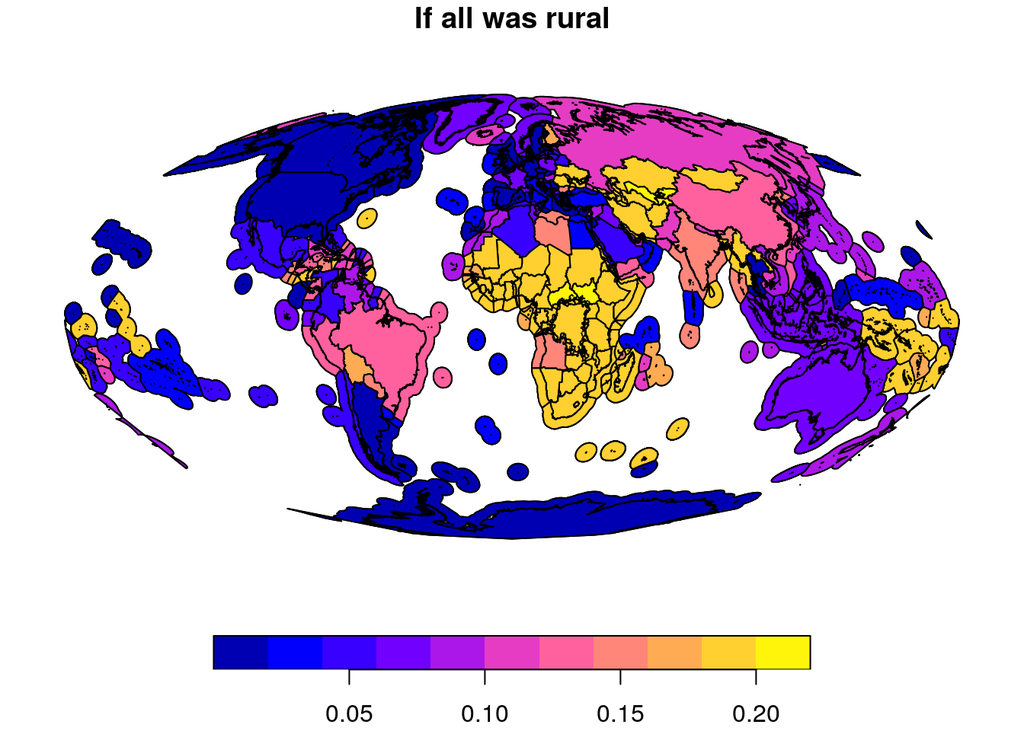

```r
plot(world_vector_sf[, "rural_sf"], main = "If all was rural")
```

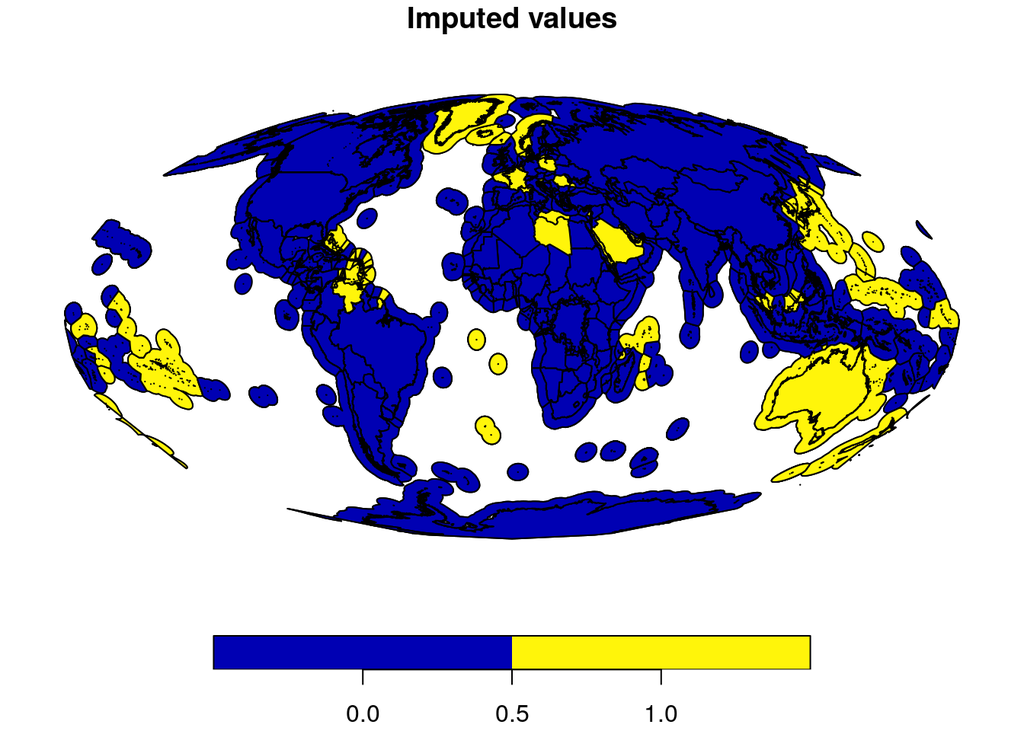

```r
plot(world_vector_sf[, "imputed_ml"], main = "Imputed values")
```

```r
rural_urban_input <-raster(rural_urban_input_fn)
# Codes: -200 = NaN, 10 = Water, 111 = Rural, 222 = Urban
rec <- c(-201, 11, NA, 11, 112, 0, 113, 223, 1)
recmat <- matrix(rec, ncol = 3, byrow = T)

rural_urban_input <- reclassify(x = rural_urban_input,
                                rcl = recmat)
```

```r
river <- raster(riv_30s_coastlines_fn) #load river raster
```

## Rasterize

Now that the fudge factors are attributed to polygons, we’ll rasterize them.

```r
sf_raster_urban <- fasterize(sf = world_vector_sf,
                             raster = rural_urban_input,
                             field = "urban_sf")

sf_raster_rural <- fasterize(sf = world_vector_sf,
                             raster = rural_urban_input,
                             field = "rural_sf")

sf_raster_urban_septic <- fasterize(sf = world_vector_sf,
                             raster = rural_urban_input,
                             field = "urban_sf_septic")

sf_raster_rural_septic <- fasterize(sf = world_vector_sf,
                             raster = rural_urban_input,
                             field = "rural_sf_septic")
```

```r
sf_raster_rural_urban <- sf_raster_urban
sf_raster_rural_urban[rural_urban_input == 0] <- sf_raster_rural[rural_urban_input == 0]
```

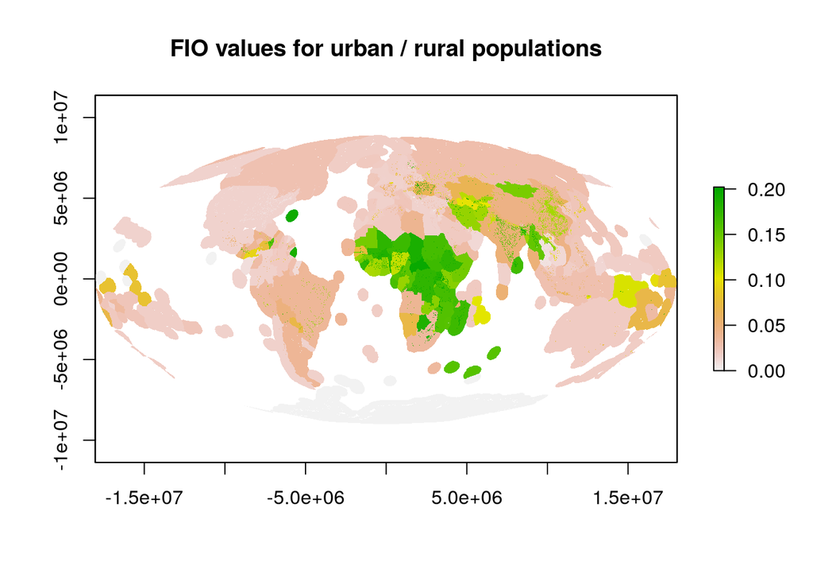

```r
plot(sf_raster_rural_urban, main = "FIO values for urban / rural populations")
```

```r
sf_raster_rural_urban_septic <- sf_raster_urban_septic
sf_raster_rural_urban_septic[rural_urban_input == 0] <- sf_raster_rural_septic[rural_urban_input == 0]
```

```r
sf_raster_rural_urban[river == 0] <- sf_raster_rural_urban_septic[river == 0]
```

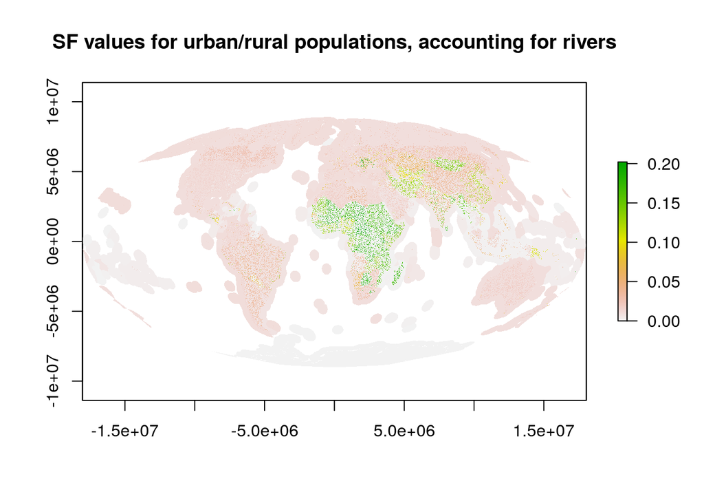

```r
plot(sf_raster_rural_urban, main = "SF values for urban/rural populations, accounting for rivers")
```

```r
file.remove(sf_raster_rural_urban_fn)
```

```
## [1] TRUE
```

```r
writeRaster(x = sf_raster_rural_urban,
            filename = sf_raster_rural_urban_fn)
```